# News articles analysis

### Basic Library Imports

```python
import numpy as np
import pandas as pd
import os
```

```python
import seaborn as sns
import matplotlib.pyplot as plt
```

```python
import csv
import json
```

### Read Data on News Articles Published from 2012-2018 [json format]

```python
data_json=pd.read_json('/users/mayurbansal/desktop/newsarticles.json',lines=True)
```

```python
data_json
```

|  | category | headline | authors | link | short_description | date |
| --- | --- | --- | --- | --- | --- | --- |
| 0 | CRIME | There Were 2 Mass Shootings In Texas Last Week... | Melissa Jeltsen | https://www.huffingtonpost.com/entry/texas-ama... | She left her husband. He killed their children... | 2018-05-26 |
| 1 | ENTERTAINMENT | Will Smith Joins Diplo And Nicky Jam For The 2... | Andy McDonald | https://www.huffingtonpost.com/entry/will-smit... | Of course it has a song. | 2018-05-26 |
| 2 | ENTERTAINMENT | Hugh Grant Marries For The First Time At Age 57 | Ron Dicker | https://www.huffingtonpost.com/entry/hugh-gran... | The actor and his longtime girlfriend Anna Ebe... | 2018-05-26 |
| 3 | ENTERTAINMENT | Jim Carrey Blasts 'Castrato' Adam Schiff And D... | Ron Dicker | https://www.huffingtonpost.com/entry/jim-carre... | The actor gives Dems an ass-kicking for not fi... | 2018-05-26 |
| 4 | ENTERTAINMENT | Julianna Margulies Uses Donald Trump Poop Bags... | Ron Dicker | https://www.huffingtonpost.com/entry/julianna-... | The "Dietland" actress said using the bags is ... | 2018-05-26 |
| ... | ... | ... | ... | ... | ... | ... |
| 200848 | TECH | RIM CEO Thorsten Heins' 'Significant' Plans Fo... | Reuters, Reuters | https://www.huffingtonpost.com/entry/rim-ceo-t... | Verizon Wireless and AT&T are already promotin... | 2012-01-28 |
| 200849 | SPORTS | Maria Sharapova Stunned By Victoria Azarenka I... |  | https://www.huffingtonpost.com/entry/maria-sha... | Afterward, Azarenka, more effusive with the pr... | 2012-01-28 |
| 200850 | SPORTS | Giants Over Patriots, Jets Over Colts Among M... |  | https://www.huffingtonpost.com/entry/super-bow... | Leading up to Super Bowl XLVI, the most talked... | 2012-01-28 |
| 200851 | SPORTS | Aldon Smith Arrested: 49ers Linebacker Busted ... |  | https://www.huffingtonpost.com/entry/aldon-smi... | CORRECTION: An earlier version of this story i... | 2012-01-28 |
| 200852 | SPORTS | Dwight Howard Rips Teammates After Magic Loss ... |  | https://www.huffingtonpost.com/entry/dwight-ho... | The five-time all-star center tore into his te... | 2012-01-28 |

200853 rows × 6 columns

#### The data contains the category of news, the headline, the author, the link, short description of news and date of publish

```python
data_json['category'].value_counts()
```

```
POLITICS          32739
WELLNESS          17827
ENTERTAINMENT     16058
TRAVEL             9887
STYLE & BEAUTY     9649
PARENTING          8677
HEALTHY LIVING     6694
QUEER VOICES       6314
FOOD & DRINK       6226
BUSINESS           5937
COMEDY             5175
SPORTS             4884
BLACK VOICES       4528
HOME & LIVING      4195
PARENTS            3955
THE WORLDPOST      3664
WEDDINGS           3651
WOMEN              3490
IMPACT             3459
DIVORCE            3426
CRIME              3405
MEDIA              2815
WEIRD NEWS         2670
GREEN              2622
WORLDPOST          2579
RELIGION           2556
STYLE              2254
SCIENCE            2178
WORLD NEWS         2177
TASTE              2096
TECH               2082
MONEY              1707
ARTS               1509
FIFTY              1401
GOOD NEWS          1398
ARTS & CULTURE     1339
ENVIRONMENT        1323
COLLEGE            1144
LATINO VOICES      1129
CULTURE & ARTS     1030
EDUCATION          1004
Name: category, dtype: int64
```

#### The news consists of various categories from politics to comedy

### Getting the date values and extracting year from the data

```python
data_json['date']=pd.to_datetime(data_json['date'])
```

```python
data_json['year']=data_json['date'].dt.year
```

### Part 1 of Analysis [Trends in Fitness Industry[2012-2018]]

```python
fitness=data_json[(data_json['category']=='HEALTHY LIVING') | (data_json['category']=='WELLNESS')]
```

```python
fitness
```

|  | category | headline | authors | link | short_description | date | year |
| --- | --- | --- | --- | --- | --- | --- | --- |
| 7578 | HEALTHY LIVING | To The People Who Say ‘I’m Tired’ When Someone... | The Mighty, ContributorWe face disability, dis... | https://www.huffingtonpost.com/entry/to-the-pe... | When you feel like this, it’s important to kno... | 2018-01-16 | 2018 |
| 7693 | HEALTHY LIVING | Eating Shake Shack Made Me Feel Healthier Than... | Colleen Werner, ContributorCampus Editor-at-Large | https://www.huffingtonpost.com/entry/eating-sh... | I can vividly remember the first time I felt f... | 2018-01-12 | 2018 |
| 7747 | HEALTHY LIVING | How To Stay Updated On The News Without Losing... | Lindsay Holmes | https://www.huffingtonpost.com/entry/anxiety-f... | Because it's only becoming more of a struggle. | 2018-01-12 | 2018 |
| 7927 | HEALTHY LIVING | 27 Perfect Tweets About Whole30 That Will Make... | Lindsay Holmes | https://www.huffingtonpost.com/entry/tweets-ab... | "The only Whole30 I want to participate in is ... | 2018-01-10 | 2018 |
| 7934 | HEALTHY LIVING | The Real Reason Your Hands Are Always Cold | Refinery29, ContributorThe #1 new-media brand ... | https://www.huffingtonpost.com/entry/the-real-... | Essentially, your hands are kept warm thanks t... | 2018-01-10 | 2018 |
| ... | ... | ... | ... | ... | ... | ... | ... |
| 200797 | WELLNESS | Shoveling Snow? How to Protect Your Back (And ... |  | https://www.huffingtonpost.com/entry/shovel-sn... | Work up to it. Warm up inside, and incorporate... | 2012-01-28 | 2012 |
| 200799 | WELLNESS | 7 Reasons Working Too Much Is Bad For Your Health | Sarah Klein | https://www.huffingtonpost.com/entry/overtime-... | If you're the last one to leave the office, or... | 2012-01-28 | 2012 |
| 200800 | WELLNESS | The Sleep Library: 11 Soothing Books For Bedtime |  | https://www.huffingtonpost.comhttp://www.oprah... | Do you toss and turn until you finally sit up ... | 2012-01-28 | 2012 |
| 200802 | WELLNESS | The Benefits of Caring for a Pet | Rita Altman, R.N., Contributor\nSenior Vice Pr... | https://www.huffingtonpost.com/entry/pets-seni... | For the young as well as the old, especially i... | 2012-01-28 | 2012 |
| 200805 | WELLNESS | This Is Only the Beginning: Surprising Advice ... | Ellie Knaus, Contributor\nAtomic Moms Podcast ... | https://www.huffingtonpost.com/entry/life-tips... | My great-aunt Ida loves to say, "This is only ... | 2012-01-28 | 2012 |

24521 rows × 7 columns

### here I manage to include all articles from WELLNESS AND HEALTHY LIVING categories to get the context of articles related to the fitness world

```python
import nltk
from nltk import FreqDist
```

```python
import pyLDAvis
import pyLDAvis.gensim
```

### Frequently Used words in Fitness articles [2012-2018]

```python
## Frequent Words Function
def freq_words(x,terms):
    all_words=' '.join([text for text in x])
    all_words=all_words.split()
    fd=FreqDist(all_words)
    words_df=pd.DataFrame({'word':list(fd.keys()),'count':list(fd.values())})
    d=words_df.nlargest(columns='count',n=terms)
    plt.figure(figsize=(16,8))
    ax=sns.barplot(data=d,x='word',y='count',palette='winter')
    ax.set(ylabel='count')
    plt.show()
```

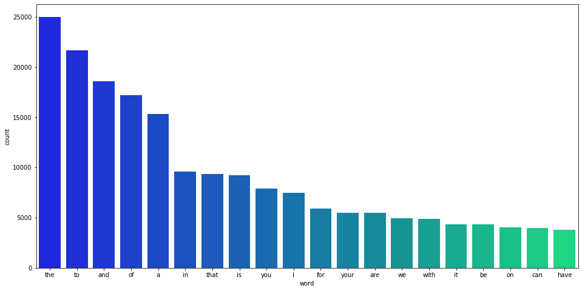

```python
freq_words(fitness['short_description'],20)
```

#### A lot of these words are extremely common in all contexts so we need to get rid of these by using the stop words to limit words like 'the','and','of' etc

```python
from nltk.corpus import stopwords
stop_words=stopwords.words('english')
pers_stop_words= ['people','could','think','would','things','something','world','years','first','there','better','every']
```

#### Here I also incorporate personalized stop words from fitness world to get better analysis of the articles

```python
# function to remove stopwords
def remove_stopwords(rev):
    rev_new = " ".join([i for i in rev if i not in stop_words and i not in pers_stop_words])
    return rev_new
```

```python
# remove short words (length < 5)
fitness['short_description'] = fitness['short_description'].apply(lambda x: ' '.join([w for w in x.split() if len(w)>4]))

# remove stopwords from the text
desc = [remove_stopwords(r.split()) for r in fitness['short_description']]

# make entire text lowercase
desc = [r.lower() for r in desc]

# remove unwanted characters, numbers and symbols
fitness['short_description'] = fitness['short_description'].str.replace("[^a-zA-Z#]", " ")
```

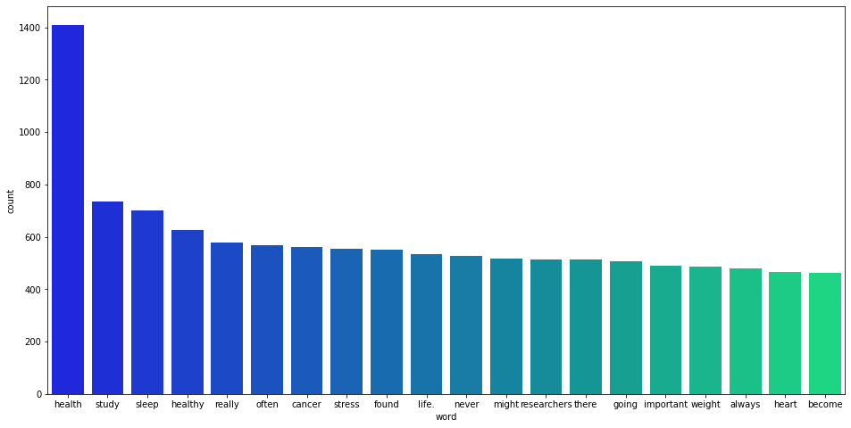

```python
freq_words(desc, 20)
```

#### Frequent word analysis shows us the words which have been used extensively in past few years. This includes words like health, sleep, cancer, stress, heart, weight etc. But to extract more context out of it, I have used TF-IDF based Topic Modeling using LDA.

```python
import sklearn
from sklearn.feature_extraction.text import TfidfVectorizer
```

### TF-IDF

```python
text=fitness['short_description']
```

```python
vectorizer=TfidfVectorizer()
```

```python
vectorizer.fit(text)
```

```
TfidfVectorizer()
```

```python
#print(vectorizer.vocabulary_)
```

```python
print(vectorizer.idf_)
```

```
[ 9.49788804 10.41417877 10.41417877 ... 10.41417877 10.41417877
 10.41417877]
```

```python
vector = vectorizer.transform(text)
```

```python
print(vector.shape)
print(vector.toarray())
```

```
(24521, 23981)
[[0. 0. 0. ... 0. 0. 0.]
 [0. 0. 0. ... 0. 0. 0.]
 [0. 0. 0. ... 0. 0. 0.]
 ...
 [0. 0. 0. ... 0. 0. 0.]
 [0. 0. 0. ... 0. 0. 0.]
 [0. 0. 0. ... 0. 0. 0.]]
```

```python
idf_scores=pd.DataFrame(vector.toarray())
```

```python
idf_scores
```

|  | 0 | 1 | 2 | 3 | 4 | 5 | 6 | 7 | 8 | 9 | ... | 23971 | 23972 | 23973 | 23974 | 23975 | 23976 | 23977 | 23978 | 23979 | 23980 |
| --- | --- | --- | --- | --- | --- | --- | --- | --- | --- | --- | --- | --- | --- | --- | --- | --- | --- | --- | --- | --- | --- |
| 0 | 0.0 | 0.0 | 0.0 | 0.0 | 0.0 | 0.0 | 0.0 | 0.0 | 0.0 | 0.0 | ... | 0.0 | 0.0 | 0.0 | 0.0 | 0.0 | 0.0 | 0.0 | 0.0 | 0.0 | 0.0 |
| 1 | 0.0 | 0.0 | 0.0 | 0.0 | 0.0 | 0.0 | 0.0 | 0.0 | 0.0 | 0.0 | ... | 0.0 | 0.0 | 0.0 | 0.0 | 0.0 | 0.0 | 0.0 | 0.0 | 0.0 | 0.0 |
| 2 | 0.0 | 0.0 | 0.0 | 0.0 | 0.0 | 0.0 | 0.0 | 0.0 | 0.0 | 0.0 | ... | 0.0 | 0.0 | 0.0 | 0.0 | 0.0 | 0.0 | 0.0 | 0.0 | 0.0 | 0.0 |
| 3 | 0.0 | 0.0 | 0.0 | 0.0 | 0.0 | 0.0 | 0.0 | 0.0 | 0.0 | 0.0 | ... | 0.0 | 0.0 | 0.0 | 0.0 | 0.0 | 0.0 | 0.0 | 0.0 | 0.0 | 0.0 |
| 4 | 0.0 | 0.0 | 0.0 | 0.0 | 0.0 | 0.0 | 0.0 | 0.0 | 0.0 | 0.0 | ... | 0.0 | 0.0 | 0.0 | 0.0 | 0.0 | 0.0 | 0.0 | 0.0 | 0.0 | 0.0 |
| ... | ... | ... | ... | ... | ... | ... | ... | ... | ... | ... | ... | ... | ... | ... | ... | ... | ... | ... | ... | ... | ... |
| 24516 | 0.0 | 0.0 | 0.0 | 0.0 | 0.0 | 0.0 | 0.0 | 0.0 | 0.0 | 0.0 | ... | 0.0 | 0.0 | 0.0 | 0.0 | 0.0 | 0.0 | 0.0 | 0.0 | 0.0 | 0.0 |
| 24517 | 0.0 | 0.0 | 0.0 | 0.0 | 0.0 | 0.0 | 0.0 | 0.0 | 0.0 | 0.0 | ... | 0.0 | 0.0 | 0.0 | 0.0 | 0.0 | 0.0 | 0.0 | 0.0 | 0.0 | 0.0 |
| 24518 | 0.0 | 0.0 | 0.0 | 0.0 | 0.0 | 0.0 | 0.0 | 0.0 | 0.0 | 0.0 | ... | 0.0 | 0.0 | 0.0 | 0.0 | 0.0 | 0.0 | 0.0 | 0.0 | 0.0 | 0.0 |
| 24519 | 0.0 | 0.0 | 0.0 | 0.0 | 0.0 | 0.0 | 0.0 | 0.0 | 0.0 | 0.0 | ... | 0.0 | 0.0 | 0.0 | 0.0 | 0.0 | 0.0 | 0.0 | 0.0 | 0.0 | 0.0 |
| 24520 | 0.0 | 0.0 | 0.0 | 0.0 | 0.0 | 0.0 | 0.0 | 0.0 | 0.0 | 0.0 | ... | 0.0 | 0.0 | 0.0 | 0.0 | 0.0 | 0.0 | 0.0 | 0.0 | 0.0 | 0.0 |

24521 rows × 23981 columns

```python
idf_df=pd.DataFrame(vector.toarray(), columns=vectorizer.get_feature_names())
idf_df.head()
```

|  | aaron | aarp | ab | aback | abadiania | abandon | abandoned | abandoning | abandonment | abate | ... | zoster | zucchini | zuckerberg | zukav | zukerman | zumba | zuravleff | zurich | zusak | zzzs |
| --- | --- | --- | --- | --- | --- | --- | --- | --- | --- | --- | --- | --- | --- | --- | --- | --- | --- | --- | --- | --- | --- |
| 0 | 0.0 | 0.0 | 0.0 | 0.0 | 0.0 | 0.0 | 0.0 | 0.0 | 0.0 | 0.0 | ... | 0.0 | 0.0 | 0.0 | 0.0 | 0.0 | 0.0 | 0.0 | 0.0 | 0.0 | 0.0 |
| 1 | 0.0 | 0.0 | 0.0 | 0.0 | 0.0 | 0.0 | 0.0 | 0.0 | 0.0 | 0.0 | ... | 0.0 | 0.0 | 0.0 | 0.0 | 0.0 | 0.0 | 0.0 | 0.0 | 0.0 | 0.0 |
| 2 | 0.0 | 0.0 | 0.0 | 0.0 | 0.0 | 0.0 | 0.0 | 0.0 | 0.0 | 0.0 | ... | 0.0 | 0.0 | 0.0 | 0.0 | 0.0 | 0.0 | 0.0 | 0.0 | 0.0 | 0.0 |
| 3 | 0.0 | 0.0 | 0.0 | 0.0 | 0.0 | 0.0 | 0.0 | 0.0 | 0.0 | 0.0 | ... | 0.0 | 0.0 | 0.0 | 0.0 | 0.0 | 0.0 | 0.0 | 0.0 | 0.0 | 0.0 |
| 4 | 0.0 | 0.0 | 0.0 | 0.0 | 0.0 | 0.0 | 0.0 | 0.0 | 0.0 | 0.0 | ... | 0.0 | 0.0 | 0.0 | 0.0 | 0.0 | 0.0 | 0.0 | 0.0 | 0.0 | 0.0 |

5 rows × 23981 columns

```python
average_idf_scores=idf_df.mean()
```

```python
average_idf_scores.sort_values(ascending=False)
```

```
about        0.013716
people       0.012551
there        0.011594
health       0.011438
being        0.009752
               ...
surplus      0.000006
greetings    0.000006
gratus       0.000006
diogenes     0.000005
ponging      0.000005
Length: 23981, dtype: float64
```

#### TF-IDF produces a sparse matrix since there are over 10000 different words used and to get context out of those based on term frequency and inverse document frequency we get extremely small numbers but here the significance is relative to other words which gets more substancial significance when discovering hidden semantic structures in LDA Topic Modeling

### LDA[Topic Modeling]

```python
from sklearn.decomposition import NMF, LatentDirichletAllocation
from sklearn.feature_extraction.text import TfidfVectorizer, CountVectorizer
```

```python
no_topics=10
no_features=1000
lda_vectorizer=TfidfVectorizer(max_df=0.95,min_df=2,max_features=no_features)
```

```python
tf = lda_vectorizer.fit_transform(text)
```

```python
lda=LatentDirichletAllocation(n_components=10,max_iter=5,learning_method='online',learning_offset=50,random_state=0).fit(tf)
```

```python
def print_top_words(model, feature_names, n_top_words):
    for topic_id, topic in enumerate(model.components_):
        print('\nTopic Nr.%d:' % int(topic_id + 1))
        print(''.join([feature_names[i] + ' ' + str(round(topic[i], 2))
              +' | ' for i in topic.argsort()[:-n_top_words - 1:-1]]))
```

```python
n_top_words = 5
lda_feature_names = lda_vectorizer.get_feature_names()
print_top_words(lda, lda_feature_names, n_top_words)
```

```
Topic Nr.1:
health 118.5 | relationship 107.86 | medical 94.84 | mental 79.92 | national 73.43 |

Topic Nr.2:
about 157.76 | don 133.15 | world 120.27 | every 118.93 | before 113.31 |

Topic Nr.3:
re 323.78 | you 314.85 | we 169.86 | study 169.56 | ve 131.76 |

Topic Nr.4:
sleep 222.12 | practice 138.53 | human 112.62 | think 102.77 | isn 97.47 |

Topic Nr.5:
exercise 146.91 | stress 141.93 | percent 128.09 | being 123.89 | here 121.46 |

Topic Nr.6:
cancer 141.16 | sometimes 112.35 | women 104.84 | night 90.68 | patients 87.06 |

Topic Nr.7:
during 110.12 | everyone 108.05 | being 100.14 | well 97.46 | little 93.7 |

Topic Nr.8:
health 114.41 | research 110.38 | brain 90.04 | studies 85.46 | children 84.95 |

Topic Nr.9:
researchers 185.76 | com 125.79 | year 119.05 | found 118.5 | attention 92.08 |

Topic Nr.10:
foods 108.01 | fitness 104.68 | can 95.96 | things 83.6 | feeling 82.51 |
```

### To go with 10 topics, we get these 10 different groups of topics which are used collectively more often across all the fitness articles. This provides a better contextual analysis than the frequent word/ bag of word approach.

### We can see how Mental Health [Topic 1] , Sleep Practice [Topic 4], Cancer [Topic 6 ]describe a pattern of what topics have stood out in the fitness articles that were gathered for this analysis.

### In fact in topic 6 we notice cancer, women, night occuring together. This could be due to a lot of articles focusing on increased risk of cancer in women who work night shifts for a longer period of time. This shows how topic analysis can lead to better discovery of hidden semantic structures

### Part 2: Designing Recommender System to recommend similar articles

#### note: here we use all the categories and not just fitness category since we would want recommender system to find articles similar in nature irrespective of the category they belong to

```python
headline_vectorizer = CountVectorizer()
headline_features   = headline_vectorizer.fit_transform(data_json['headline'])
```

```python
from sklearn.metrics.pairwise import cosine_similarity
from sklearn.metrics import pairwise_distances
```

### 1st approach: Frequent words appraoch to recommend articles

```python
def frequentwordsrecommender(row_index, num_similar_items):
    couple_dist = pairwise_distances(headline_features,headline_features[row_index])
    indices = np.argsort(couple_dist.ravel())[0:num_similar_items]
    df = pd.DataFrame({'publish_date': data_json['date'][indices].values,
               'headline':data_json['headline'][indices].values,
                'Euclidean similarity with the queried article': couple_dist[indices].ravel()})
    print("="*30,"Queried article details","="*30)
    print('headline : ',data_json['headline'][indices[0]])
    print("\n","="*25,"Recommended articles : ","="*23)
    return df.sort_values(by='Euclidean similarity with the queried article',ascending=False)
```

```python
frequentwordsrecommender(1, 10)
```

```
============================== Queried article details ==============================
headline :  Will Smith Joins Diplo And Nicky Jam For The 2018 World Cup's Official Song

 ========================= Recommended articles :  =======================
```

|  | publish_date | headline | Euclidean similarity with the queried article |
| --- | --- | --- | --- |
| 5 | 2014-08-15 | ISIS and the G-41 World | 3.605551 |
| 6 | 2014-08-28 | Service for a Song | 3.605551 |
| 7 | 2012-12-17 | And I Will Cry... | 3.605551 |
| 8 | 2016-08-20 | TRUMP AND THE 1% | 3.605551 |
| 9 | 2012-01-28 | Tinker and Change the World | 3.605551 |
| 2 | 2014-07-14 | The World Financial Cup | 3.464102 |
| 3 | 2012-01-31 | A Film By And For The World | 3.464102 |
| 4 | 2014-07-12 | Sport and Society for Arete -- The World Cup | 3.464102 |
| 1 | 2014-07-16 | The World Cup and Baseball | 3.316625 |
| 0 | 2018-05-26 | Will Smith Joins Diplo And Nicky Jam For The 2... | 0.000000 |

### Let us see how a TF-IDF based recommender system does to gain more context in recommending articles

```python
tfidf_headline_vectorizer = TfidfVectorizer(min_df = 0)
tfidf_headline_features = tfidf_headline_vectorizer.fit_transform(data_json['headline'])
```

```python
def tfidfrecom(row_index, num_similar_items):
    couple_dist = pairwise_distances(tfidf_headline_features,tfidf_headline_features[row_index])
    indices = np.argsort(couple_dist.ravel())[0:num_similar_items]
    df = pd.DataFrame({'publish_date': data_json['date'][indices].values,
               'headline':data_json['headline'][indices].values,
                'Euclidean similarity with the queried article': couple_dist[indices].ravel()})
    print("="*30,"Queried article details","="*30)
    print('headline : ',data_json['headline'][indices[0]])
    print("\n","="*25,"Recommended articles : ","="*23)
    return df.sort_values(by='Euclidean similarity with the queried article',ascending=False)
```

```python
tfidfrecom(1, 10)
```

```
============================== Queried article details ==============================
headline :  Will Smith Joins Diplo And Nicky Jam For The 2018 World Cup's Official Song

 ========================= Recommended articles :  =======================
```

|  | publish_date | headline | Euclidean similarity with the queried article |
| --- | --- | --- | --- |
| 9 | 2018-01-16 | A Nicky Jam Bio-Series Is Coming To Netflix | 1.149145 |
| 1 | 2015-01-25 |  | 1.000000 |
| 2 | 2015-08-22 |  | 1.000000 |
| 3 | 2014-06-02 | R.I.P. | 1.000000 |
| 4 | 2016-06-05 | L O V E | 1.000000 |
| 5 | 2015-01-13 |  | 1.000000 |
| 6 | 2014-08-28 |  | 1.000000 |
| 7 | 2015-03-29 |  | 1.000000 |
| 8 | 2015-06-30 |  | 1.000000 |
| 0 | 2018-05-26 | Will Smith Joins Diplo And Nicky Jam For The 2... | 0.000000 |

### To summarize, this document tries to focus on 2 main things:

1) Finding the trends in fitness articles based on how articles are framed 2) Building some simpler and quick to analyze recommender system approaches to find similar yet diverse set of recommended articles

### Further Works

I would like to dive into more recent news articles preferably from 2019 and 2020 to get recent analysis. Also, would like to merge Twitter data using TWEEPY package to get comprehensive data for further analysis [Already work in progress]

In terms of the above discussed recommender system approaches, I would like to add more filters based on published date, author who published the article, geographical data etc to add weight to the effectiveness of recommendations.

Happy to brainstorm on other approaches from anyone who has similar interests in the same